# 重回帰分析

Yuki Tanida

#### 相関プロット

３つの変数y、x1、x2のデータは、次のような相関関係を持つように生成された。

[output not shown]

[output not shown]

```
## x1とx2の相関：r =  0.3992953
```

[figure not shown]

#### 単回帰

##### y ~ x1

ｙを切片とx1で予測する単回帰分析の結果は次の通り。  
Constantはintercepr（切片）のこと。

```
##
## ===============================================
##                         Dependent variable:
##                     ---------------------------
##                                  y
## -----------------------------------------------
## x1                         0.493 (0.096)
##                              t = 5.112
##                             p = 0.00001
## Constant                   0.131 (0.102)
##                              t = 1.292
##                              p = 0.200
## -----------------------------------------------
## Observations                    100
## R2                             0.211
## Adjusted R2                    0.202
## Residual Std. Error       1.015 (df = 98)
## F Statistic           26.137*** (df = 1; 98)
## ===============================================
## Note:               *p<0.1; **p<0.05; ***p<0.01
```

切片と傾きを図示すると左図のようになる。  
右図のように直線を引くと残差平方和が最小にならない。

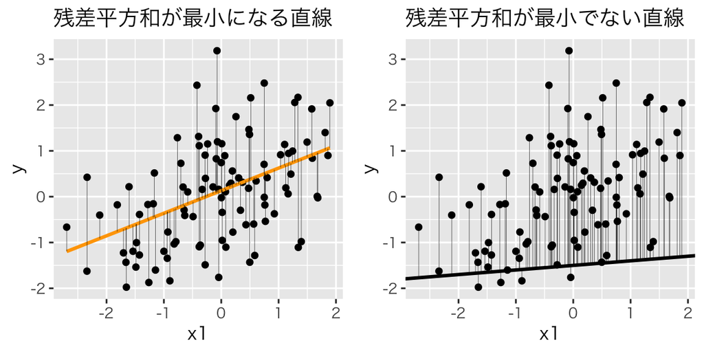

##### y ~ x2

ｙを切片とx2で予測する単回帰分析の結果は次の通り。

```
##
## ===============================================
##                         Dependent variable:
##                     ---------------------------
##                                  y
## -----------------------------------------------
## x2                         0.416 (0.096)
##                              t = 4.311
##                             p = 0.00004
## Constant                   0.097 (0.105)
##                              t = 0.931
##                              p = 0.355
## -----------------------------------------------
## Observations                    100
## R2                             0.159
## Adjusted R2                    0.151
## Residual Std. Error       1.047 (df = 98)
## F Statistic           18.588*** (df = 1; 98)
## ===============================================
## Note:               *p<0.1; **p<0.05; ***p<0.01
```

切片と傾きを図示すると左図のようになる。  
右図のように直線を引くと残差平方和が最小にならない。

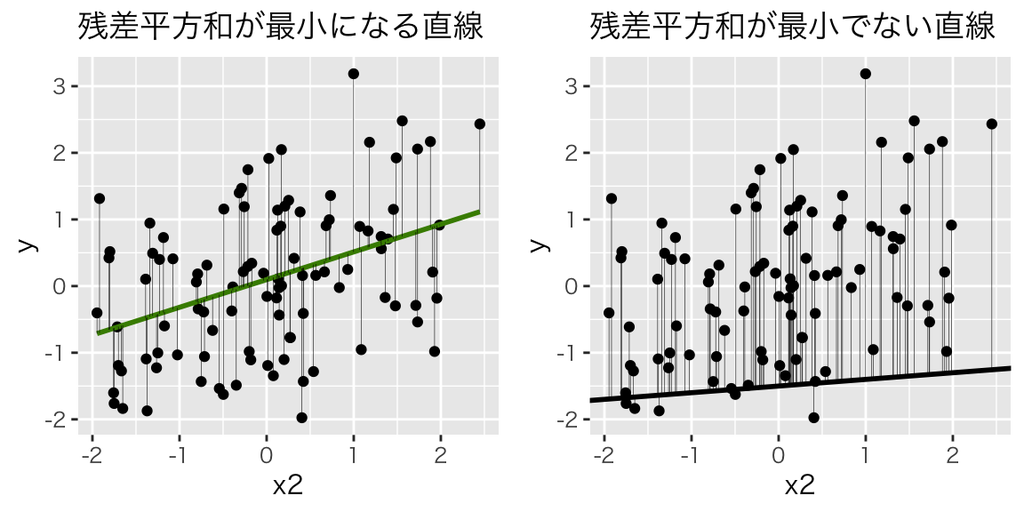

#### 重回帰：y ~ x1 + x2

ｙを切片とx1とx2で予測する重回帰分析の結果は次の通り。

```
##
## ===============================================
##                         Dependent variable:
##                     ---------------------------
##                                  y
## -----------------------------------------------
## x1                         0.393 (0.098)
##                              t = 3.988
##                             p = 0.0002
## x2                         0.287 (0.095)
##                              t = 3.007
##                              p = 0.004
## Constant                   0.122 (0.098)
##                              t = 1.245
##                              p = 0.217
## -----------------------------------------------
## Observations                    100
## R2                             0.278
## Adjusted R2                    0.263
## Residual Std. Error       0.975 (df = 97)
## F Statistic           18.661*** (df = 2; 97)
## ===============================================
## Note:               *p<0.1; **p<0.05; ***p<0.01
```

x1-y平面とy-x2平面に回帰直線を引くと次のようになる。  
橙色と緑色の直線は単回帰をした場合の直線。変数間に相関があるため、少しズレているのがわかる。

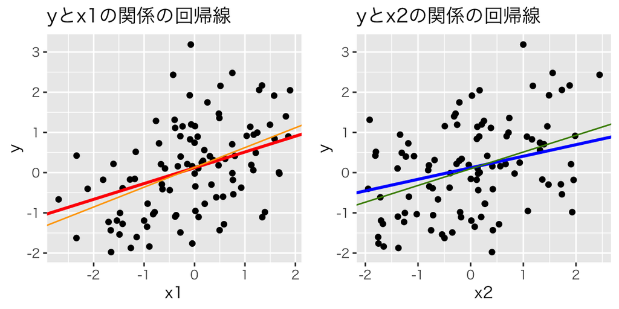

##### 回帰平面

[interactive chart not shown]

##### 重回帰直線の位置

重回帰分析のy - x1の関係を示す回帰直線（赤）は、x2 = 0の位置のもの  
重回帰分析のy - x2の関係を示す回帰直線（青）は、x1 = 0の位置のもの

[interactive chart not shown]

##### 単回帰直線との比較

yをx1もしくはx2でだけ予測した単回帰直線を描画すると、次のようになる。  
y ~ x1の単回帰直線（橙）  
y ~ x2の単回帰直線（緑）

[interactive chart not shown]

Copyright (c) 2022 Yuki Tanida  
This website content is released under the CC BY 4.0 License, see CC_LICENSE.